# The influence of reward on facial mimicry: no evidence for a significant effect of oxytocin.

Statistical analyses

Irene Trilla, Hanna Drimalla, Malek Bajbouj, Isabel Dziobek

28.04.2020

# Sample

```r
# create summary table split by treatment groups
quest_table <- furniture::table1(d.quest, 'Age'=age, 'Autism Spectrum Quotient (AQ)'=aq, 'Empathy Quotient (EQ)'=eq, 'Mehrfachwahl-Wortschatz-Intelligenztest-B (MWT-B)'=mwt, splitby=~treatment,
                    na.rm=FALSE, test=FALSE, total=TRUE, digits=2, type='condense')

kable(quest_table, align='l', caption='Mean (SD) age and questionnaire scores for the full sample, and for each treatment group:') %>%
  kable_styling(bootstrap_options = c("hover", "condensed", "responsive"))
```

Mean (SD) age and questionnaire scores for the full sample, and for each treatment group:

| . | Total | Placebo | Oxytocin |
| --- | --- | --- | --- |
|  | n = 60 | n = 30 | n = 30 |
| Age | 27.40 (6.03) | 29.10 (6.04) | 25.70 (5.61) |
| Autism Spectrum Quotient (AQ) | 8.40 (4.69) | 8.87 (4.01) | 7.93 (5.31) |
| Empathy Quotient (EQ) | 36.33 (10.49) | 36.10 (11.08) | 36.57 (10.04) |
| Mehrfachwahl-Wortschatz-Intelligenztest-B (MWT-B) | 26.67 (4.58) | 27.33 (4.82) | 26.00 (4.32) |

*Note*: as participants were randomly assigned to the treatment groups, we did not perform balance tests with respect to age, autistic traits, empathy or verbal intelligence. See [janhove.github.io](https://janhove.github.io/reporting/2014/09/26/balance-tests), and Mutz, Pemantle and Pham (2019), for a more detailed justification.

# Blinding integrity

At the end of the experimental session, participants indicated which treatment they thought they had received (oxytocin or placebo). Overall, 37% of the participants guessed correctly, 40% made an incorrect guess, and 23% reported to not know. A chi-square test indicated that the proportion of participants who made correct, incorrect and ‘I don’t know’ responses did not significantly differ between treatment groups.

```r
# recode responses
d.quest$guess[(d.quest$treatment=='Oxytocin' & d.quest$treatment_guess=='oxt')| (d.quest$treatment=='Placebo' & d.quest$treatment_guess=='plc')] <- 'Correct'
d.quest$guess[(d.quest$treatment=='Oxytocin' & d.quest$treatment_guess=='plc')| (d.quest$treatment=='Placebo' & d.quest$treatment_guess=='oxt')] <- 'Incorrect'
d.quest$guess[d.quest$treatment_guess=='idk'] <- "I don't know"

# create summary table split by treatment groups
treatment_table <- furniture::table1(d.quest,'Guess'=guess,splitby=~treatment, na.rm=TRUE, test=TRUE, total=TRUE, type='full')
kable(treatment_table, align='l', caption='')  %>%
  kable_styling(bootstrap_options = c('hover', 'condensed', 'responsive'))
```

| . | Total | Placebo | Oxytocin | Test | P.Value |
| --- | --- | --- | --- | --- | --- |
|  | n = 60 | n = 30 | n = 30 |  |  |
| Guess |  |  |  | Chi Square: 1.49 | 0.474 |
| Correct | 22 (36.7%) | 12 (40%) | 10 (33.3%) |  |  |
| I don’t know | 14 (23.3%) | 5 (16.7%) | 9 (30%) |  |  |
| Incorrect | 24 (40%) | 13 (43.3%) | 11 (36.7%) |  |  |

# Mood

Positive and negative affect (PANAS) were assessed before treatment administration, and 35 minutes after.

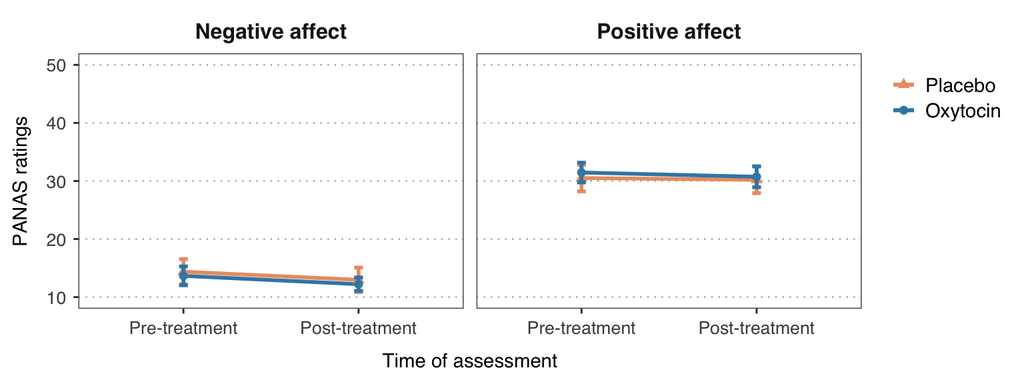

Figure 1. PANAS ratings before and after treatment administration. Error bars indicate 95% confidence intervals.

```r
panas_table <- furniture::table1(d.quest,
                    'Positive affect - Pre'=panas_pa_pre, 'Positive affect - Post'=panas_pa_post,
                    'Negative affect - Pre'=panas_na_pre, 'Negative affect - Post'=panas_na_post,
                    splitby=~treatment,na.rm=FALSE, test=FALSE, total=TRUE, digits=2,type='condense'
                    )

kable(panas_table, align='l', caption='Descriptive statistics (M, SD) on the PANAS scales Positive affect and Negative affect, at baseline (pre) and 35 minutes after treatment administration (post). PANAS ratings can range between 10 and 50 points.') %>%
  kable_styling(bootstrap_options = c('hover', 'condensed', 'responsive'))
```

Descriptive statistics (M, SD) on the PANAS scales Positive affect and Negative affect, at baseline (pre) and 35 minutes after treatment administration (post). PANAS ratings can range between 10 and 50 points.

| . | Total | Placebo | Oxytocin |
| --- | --- | --- | --- |
|  | n = 60 | n = 30 | n = 30 |
| Positive affect - Pre | 30.98 (6.91) | 30.27 (7.70) | 31.70 (6.08) |
| Positive affect - Post | 30.47 (6.95) | 29.97 (7.49) | 30.97 (6.46) |
| Negative affect - Pre | 14.02 (4.62) | 14.13 (5.08) | 13.90 (4.20) |
| Negative affect - Post | 12.60 (3.97) | 12.73 (4.77) | 12.47 (3.05) |

To check whether treatment had an effect on the participants’ mood, we ran an ANOVA with `Time` (Pre, Post) as within-subject factor, and `Treatment` (Oxytocin, Placebo) as between-subject factor, for Positive affect and Negative affect separately.

### Negative affect

Participants reported significantly less negative affect after treatment administration than at baseline. This effect was not significantly dependent on treatment group.

```r
# ANOVA: negative affect
m.na <- afex::aov_4(rating ~ time*treatment + (time|id), d.panas[d.panas$scale=='Negative affect',])
kable(nice(m.na), digits=2, caption='ANOVA on Negative affect:')  %>%
  kable_styling(bootstrap_options = c('hover', 'condensed', 'responsive'))
```

ANOVA on Negative affect:

| Effect | df | MSE | F | ges | p.value |
| --- | --- | --- | --- | --- | --- |
| treatment | 1, 58 | 33.52 | 0.06 | .0009 | .81 |
| time | 1, 58 | 4.19 | 14.35 *** | .03 | .0004 |
| treatment:time | 1, 58 | 4.19 | 0.00 | <.0001 | .96 |

### Positive affect

There were no significant changes in positive affect, neither over time nor between treatment groups.

```r
# ANOVA: positive affect
m.pa <- afex::aov_4(rating ~ time*treatment + (time|id), d.panas[d.panas$scale=='Positive affect',])
kable(nice(m.pa), caption='ANOVA on Positive affect:') %>%
  kable_styling(bootstrap_options = c('hover', 'condensed', 'responsive'))
```

ANOVA on Positive affect:

| Effect | df | MSE | F | ges | p.value |
| --- | --- | --- | --- | --- | --- |
| treatment | 1, 58 | 83.26 | 0.53 | .008 | .47 |
| time | 1, 58 | 13.71 | 0.58 | .001 | .45 |
| treatment:time | 1, 58 | 13.71 | 0.10 | .0003 | .75 |

# Reward manipulation

An associative learning paradigm was used to pair neutral faces with different reward values. On each trial, participants had to choose between one of two faces presented side by side. Two different face pairs appeared througout the task. For each pair, one face was associated with 60% probability of winning money (high reward condition), and the other face with 30% probability of winning money (low reward condition).

The task consisted of a minimum of three 10-trial blocks per face pair. Participants completed up to 4 additional 10-trial blocks per face pair if the proportion of high reward choices for that particular stimuli did not reach 80% by the end of the last block completed.

### Number of learning blocks

```r
# Descriptive statistics on the number of blocks completed
nblocks_group <- d.rew.wide %>%
  group_by(treatment) %>%
  summarize(N=length(n_blocks),
            Mean=mean(n_blocks),
            SD=sd(n_blocks),
            Min=min(n_blocks),
            Max=max(n_blocks))

nblocks_full <- d.rew.wide %>%
  summarize(treatment='Total',
            N=length(n_blocks),
            Mean=mean(n_blocks),
            SD=sd(n_blocks),
            Min=min(n_blocks),
            Max=max(n_blocks))

nblocks_descr <- rbind(nblocks_group, nblocks_full)
kable(nblocks_descr, digits=2, caption='Descriptive statistics on the number of learning blocks completed per face pair in the reward learning task:') %>%
  kable_styling(bootstrap_options = c('hover', 'condensed', 'responsive'))
```

Descriptive statistics on the number of learning blocks completed per face pair in the reward learning task:

| treatment | N | Mean | SD | Min | Max |
| --- | --- | --- | --- | --- | --- |
| Placebo | 30 | 4.15 | 1.43 | 3 | 7 |
| Oxytocin | 30 | 4.20 | 1.44 | 3 | 7 |
| Total | 60 | 4.17 | 1.42 | 3 | 7 |

A t-test revealed no significant differences in the number of blocks completed between treatment groups:

```r
# t-test comparing number of blocks completed
t.test(d.rew.wide$n_blocks ~ d.rew.wide$treatment, alternative='two.sided', paired=FALSE, var.equal=TRUE)
```

```
##
##  Two Sample t-test
##
## data:  d.rew.wide$n_blocks by d.rew.wide$treatment
## t = -0.13498, df = 58, p-value = 0.8931
## alternative hypothesis: true difference in means is not equal to 0
## 95 percent confidence interval:
##  -0.7914807  0.6914807
## sample estimates:
##  mean in group Placebo mean in group Oxytocin
##                   4.15                   4.20
```

### Number of faces learnt

```r
# create new variable with the number of face pairs learnt
d.rew.wide$n_learnt <- factor(d.rew.wide$n_facepairs_notlearnt, levels=c(0, 1, 2), labels=c('2', '1', '0'))

# contingency table and chi-squared test comparing the number of participants
# that learnt all, one or none of the face pairs by group
nlearnt_table <- furniture::table1(d.rew.wide, 'Nº face pairs learnt:'=n_learnt, splitby=~treatment,
                    na.rm=TRUE, test=TRUE, total=TRUE, type='full')

kable(nlearnt_table, align='l', caption='Number (percentage) of participants that learnt the reward associations for all face pairs (2), one face pair (1) or none (0). The face-reward associations were considered learnt if participants selected the high reward face within a pair 80% of the times in the last 10-trial-block completed.') %>%
  kable_styling(bootstrap_options = c('hover', 'condensed', 'responsive'))
```

Number (percentage) of participants that learnt the reward associations for all face pairs (2), one face pair (1) or none (0). The face-reward associations were considered learnt if participants selected the high reward face within a pair 80% of the times in the last 10-trial-block completed.

| . | Total | Placebo | Oxytocin | Test | P.Value |
| --- | --- | --- | --- | --- | --- |
|  | n = 60 | n = 30 | n = 30 |  |  |
| Nº face pairs learnt: |  |  |  | Chi Square: 0.34 | 0.842 |
| 2 | 48 (80%) | 24 (80%) | 24 (80%) |  |  |
| 1 | 7 (11.7%) | 3 (10%) | 4 (13.3%) |  |  |
| 0 | 5 (8.3%) | 3 (10%) | 2 (6.7%) |  |  |

A Chi-square test revealed no significant differences between treatment groups with respect to the number of participants that learnt all, one or none of the face-reward pairs.

### Proportion of high reward choices

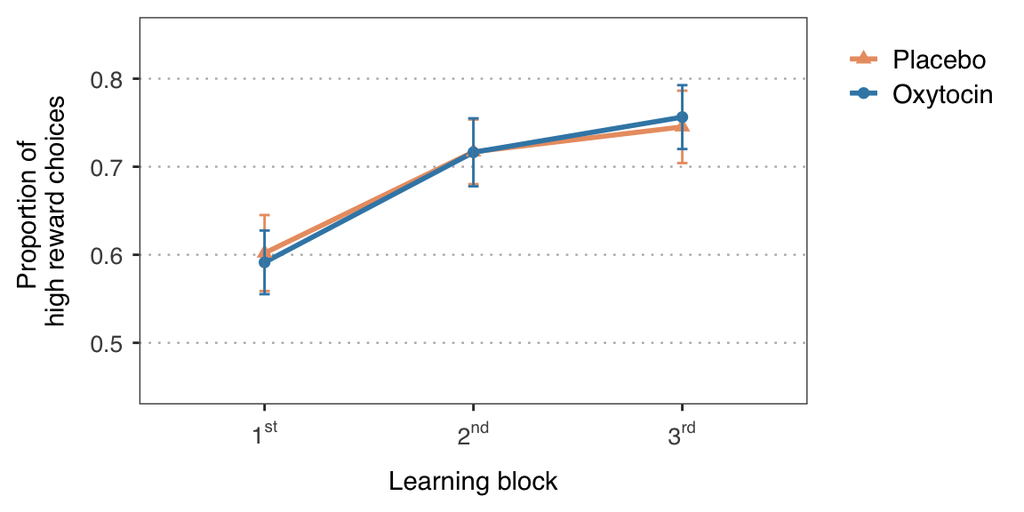

Figure 2. Proportion of high reward choices for the first 3 learning blocks of the reward learning task.

```r
# descriptive statistics
hirewprop_table <- furniture::table1(d.rew.wide,
                                   'Block 1'=prop_hirew_block_1,
                                   'Block 2'=prop_hirew_block_2,
                                   'Block 3'=prop_hirew_block_3,
                                   splitby=~treatment,
                                   na.rm=TRUE, test=FALSE, total=TRUE, type='condense', digits=2
                                   )

kable(hirewprop_table, align='l', caption='Desriptive statistics (M, SD) on the proportion of high reward choices for the first 3 reward learning blocks, averaged for both face pairs:') %>%
  kable_styling(bootstrap_options = c('hover', 'condensed', 'responsive'))
```

Desriptive statistics (M, SD) on the proportion of high reward choices for the first 3 reward learning blocks, averaged for both face pairs:

| . | Total | Placebo | Oxytocin |
| --- | --- | --- | --- |
|  | n = 60 | n = 30 | n = 30 |
| Block 1 | 0.60 (0.19) | 0.59 (0.19) | 0.60 (0.19) |
| Block 2 | 0.72 (0.21) | 0.70 (0.21) | 0.73 (0.22) |
| Block 3 | 0.75 (0.20) | 0.73 (0.21) | 0.77 (0.19) |

```r
# anova
m.cond <- afex::aov_4(prophirew ~ block*treatment + (block|id), d.rew)
kable(nice(m.cond), caption='ANOVA on the proportion of high reward choices by learning block:') %>%
  kable_styling(bootstrap_options = c('hover', 'condensed', 'responsive'))
```

ANOVA on the proportion of high reward choices by learning block:

| Effect | df | MSE | F | ges | p.value |
| --- | --- | --- | --- | --- | --- |
| treatment | 1, 58 | 0.10 | 0.26 | .004 | .61 |
| block | 1.99, 115.52 | 0.01 | 36.51 *** | .10 | <.0001 |
| treatment:block | 1.99, 115.52 | 0.01 | 0.16 | .0005 | .85 |

In line with the expected reward learning, there was a significant effect of `Block`. Post-hoc tests showed that participants chose the high reward faces more often in the second and third blocks, as compared to the first block. The difference between the second and third blocks did not reach statistical significance. There was no significant main effect of `Treatment`, nor a significant interaction `Block*Treatment`.

```r
# post-hoc tests
m.cond.emmeans <- emmeans(m.cond, c('block'))
m.cond.posthoc <- summary(update(pairs(m.cond.emmeans), by=NULL, adjust='holm'))

# effect sizes for post-hoc tests
d_pair1 <- effsize::cohen.d(d.rew$prophirew[d.rew$block=='Block 1'],d.rew$prophirew[d.rew$block=='Block 2'])
d_pair2 <- effsize::cohen.d(d.rew$prophirew[d.rew$block=='Block 1'],d.rew$prophirew[d.rew$block=='Block 3'])
d_pair3 <- effsize::cohen.d(d.rew$prophirew[d.rew$block=='Block 2'],d.rew$prophirew[d.rew$block=='Block 3'])
m.cond.posthoc$cohen.d <- c(d_pair1$estimate, d_pair2$estimate, d_pair3$estimate)

# table post-hoc results
kable(m.cond.posthoc, digits=2, caption='Follow-up test for the main effect of Block:') %>%
  kable_styling(bootstrap_options = c('hover', 'condensed', 'responsive'))
```

Follow-up test for the main effect of Block:

| contrast | estimate | SE | df | t.ratio | p.value | cohen.d |
| --- | --- | --- | --- | --- | --- | --- |
| Block.1 - Block.2 | -0.12 | 0.02 | 116 | -6.33 | 0.00 | -0.60 |
| Block.1 - Block.3 | -0.15 | 0.02 | 116 | -8.14 | 0.00 | -0.80 |
| Block.2 - Block.3 | -0.03 | 0.02 | 116 | -1.80 | 0.07 | -0.17 |

### Pleasantness ratings

To check whether the reward associations changed how faces were evaluated, participants rated the pleasantness of the neutral faces before and after the reward learning task on a 7-point scale (1 = very unpleasant; 7 = very pleasant).

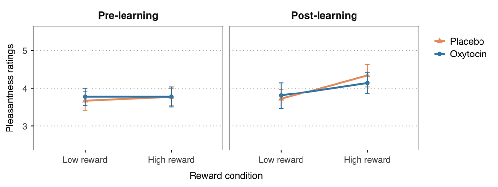

Figure 3. Mean pleasantness ratings for the faces paired with low and high reward values, before and after the reward learning task. Error bars are within-subject 95% confidence intervals.

```r
# descriptive statistics
pleasant_table <- furniture::table1(d.rew.wide,
                                    'Pre-learning: Low reward'=pleasantness_lorew_pre,
                                    'Pre-learning: High reward'=pleasantness_hirew_pre,
                                    'Post-learning: Low reward'=pleasantness_lorew_post,
                                    'Post-learning: High reward'=pleasantness_hirew_post,
                                    splitby=~treatment,
                                    na.rm=TRUE, test=FALSE, total=TRUE, type='condense', digits=2
                                    )

kable(pleasant_table, align='l', caption='Mean pleasantness ratings (SD) of the neutral faces before and after the reward learning task:') %>%
  kable_styling(bootstrap_options = c('hover', 'condensed', 'responsive'))
```

Mean pleasantness ratings (SD) of the neutral faces before and after the reward learning task:

| . | Total | Placebo | Oxytocin |
| --- | --- | --- | --- |
|  | n = 60 | n = 30 | n = 30 |
| Pre-learning: Low reward | 3.72 (0.71) | 3.75 (0.76) | 3.68 (0.66) |
| Pre-learning: High reward | 3.77 (0.89) | 3.85 (0.78) | 3.68 (0.99) |
| Post-learning: Low reward | 3.76 (0.91) | 3.80 (0.95) | 3.72 (0.88) |
| Post-learning: High reward | 4.23 (0.98) | 4.42 (0.81) | 4.05 (1.12) |

A 2 x 2 x 2 mixed ANOVA with `Reward` (High reward, Low reward) and `Time` (Pre-, Post-reward learning task) as within-subject factors, and `Treatment` (Oxytocin, Placebo) as between-subject factor was used to examine whether pleasantness ratings of the faces changed after the reward associations were learnt.

```r
m.pleasant <- afex::aov_4(rating ~ reward*time*treatment + (reward*time|id), d.pleasant)
kable(nice(m.pleasant), caption='ANOVA on pleasantness ratings before and after learning the face-reward associations:') %>%
  kable_styling(bootstrap_options = c('hover', 'condensed', 'responsive'))
```

ANOVA on pleasantness ratings before and after learning the face-reward associations:

| Effect | df | MSE | F | ges | p.value |
| --- | --- | --- | --- | --- | --- |
| treatment | 1, 58 | 1.52 | 1.16 | .010 | .29 |
| reward | 1, 58 | 0.88 | 4.69 * | .02 | .03 |
| treatment:reward | 1, 58 | 0.88 | 0.63 | .003 | .43 |
| time | 1, 58 | 0.38 | 10.10 ** | .02 | .002 |
| treatment:time | 1, 58 | 0.38 | 0.46 | .0010 | .50 |
| reward:time | 1, 58 | 0.31 | 8.74 ** | .01 | .004 |
| treatment:reward:time | 1, 58 | 0.31 | 0.41 | .0007 | .53 |

There was a change in the perceived pleasantness of the faces after the reward learning task, indicated by a significant interaction `Reward*Time`. As shown in the follow-up tests, while there were no significant differences in pleasantness ratings at baseline, faces associated with high reward were rated as more pleasant than faces associated with low reward after the reward learning task. Treatment did not significantly interact with these effects, nor had an overall influence on pleasantness ratings.

```r
# tailored contrasts for post-hoc tests
posthoc_contr <- list('Low reward: Pre vs. Post'  =c(1, -1, 0, 0),
  'High reward: Pre vs. Post'  =c(0, 0, 1, -1),
  'Pre: Low reward vs. High reward' =c(1, 0, -1, 0),
  'Post: Low reward vs. High reward'=c(0, 1, 0, -1)
)

# contrasts
m.pleasant.emmeans <- emmeans(m.pleasant, c('time', 'reward'))
m.pleasant.posthoc <- summary(contrast(m.pleasant.emmeans, posthoc_contr, adjust='holm'))

# effect sizes for post-hoc tests
d_pair1 <- effsize::cohen.d(d.pleasant$rating[d.pleasant$reward=='Low reward' & d.pleasant$time=='Pre-learning'],
                            d.pleasant$rating[d.pleasant$reward=='Low reward' & d.pleasant$time=='Post-learning'])
d_pair2 <- effsize::cohen.d(d.pleasant$rating[d.pleasant$reward=='High reward' & d.pleasant$time=='Pre-learning'],
                            d.pleasant$rating[d.pleasant$reward=='High reward' & d.pleasant$time=='Post-learning'])
d_pair3 <- effsize::cohen.d(d.pleasant$rating[d.pleasant$reward=='Low reward' & d.pleasant$time=='Pre-learning'],
                            d.pleasant$rating[d.pleasant$reward=='High reward' & d.pleasant$time=='Pre-learning'])
d_pair4 <- effsize::cohen.d(d.pleasant$rating[d.pleasant$reward=='Low reward' & d.pleasant$time=='Post-learning'],
                            d.pleasant$rating[d.pleasant$reward=='High reward' & d.pleasant$time=='Post-learning'])
m.pleasant.posthoc$cohen.d <- c(d_pair1$estimate, d_pair2$estimate, d_pair3$estimate, d_pair4$estimate)

# table post-hoc results
kable(m.pleasant.posthoc, digits=2, caption='Follow-up tests for the interaction `Time*Reward`:') %>%
  kable_styling(bootstrap_options = c('hover', 'condensed', 'responsive'))
```

Follow-up tests for the interaction `Time*Reward`:

| contrast | estimate | SE | df | t.ratio | p.value | cohen.d |
| --- | --- | --- | --- | --- | --- | --- |
| Low reward: Pre vs. Post | -0.04 | 0.11 | 114.7 | -0.39 | 1 | -0.05 |
| High reward: Pre vs. Post | -0.47 | 0.11 | 114.7 | -4.34 | 0 | -0.50 |
| Pre: Low reward vs. High reward | -0.05 | 0.14 | 94.3 | -0.35 | 1 | -0.06 |
| Post: Low reward vs. High reward | -0.47 | 0.14 | 94.3 | -3.37 | 0 | -0.50 |

# Facial mimicry (EMG)

## Analysis sample

Due to technical problems, EMG data of two participants were not collected. Data from two additional participants were excluded from the EMG analyses, as they responded incorrectly in more than 20% of the attention control questions of the mimicry task.

The EMG analysis sample thus included 29 participants in the oxytocin group and 27 participants in the placebo group.

```r
# mark participants included/excluded for the emg analyses
d.quest$emg_sample <- 'included'
d.quest$emg_sample[d.quest$id==c(17, 18)] <- 'excluded due to missing EMG data'
d.quest$emg_sample[d.quest$accuracy_mimtask<0.8 & !is.na(d.quest$accuracy_mimtask)] <- 'excluded due to inattention during mimicry task'

emgsample_table <- furniture::table1(d.quest, 'Nº of participants:'=emg_sample, splitby=~treatment,
                                    na.rm=TRUE, test=FALSE, total=TRUE, type='condense')

kable(emgsample_table, align='l', caption='Number of participants (%) included and excluded from the EMG analyses:') %>%
  kable_styling(bootstrap_options = c('hover', 'condensed', 'responsive'))
```

Number of participants (%) included and excluded from the EMG analyses:

| . | Total | Placebo | Oxytocin |
| --- | --- | --- | --- |
|  | n = 60 | n = 30 | n = 30 |
| Nº of participants: |  |  |  |
| excluded due to inattention during mimicry task | 2 (3.3%) | 2 (6.7%) | 0 (0%) |
| excluded due to missing EMG data | 2 (3.3%) | 1 (3.3%) | 1 (3.3%) |
| included | 56 (93.3%) | 27 (90%) | 29 (96.7%) |

## Statistical plan

EMG data was analyzed using linear mixed models (LMM). Separate LMMs were ran to test EMG responses to observation of happy and angry facial expressions. Mimicry of happiness was defined as stronger response of ZM vs. CS when watching happy facial expressions. Mimicry of anger was defined as stronger CS vs. ZM when watching angry facial expressions.

#### Mimicry of no-reward faces

First, we ran two LMMs to examine the direct influence of oxytocin on facial mimicry of happiness (*model 1*) and of anger (*model 2*). Only data from trials in which participants viewed no-reward faces (i.e. novel faces that did not appear in the reward learning task) were fitted in these LMMs.

- Model 1:

  `[EMG scores for happy, no-reward faces] ~ Muscle + Treatment + Muscle*Treatment +` `(1|Participant) + (1|Stimuli)`
- Model 2:

  `[EMG scores for angry, no-reward faces] ~ Muscle + Treatment + Muscle*Treatment +` `(1|Participant)`

#### Mimicry of low & high reward faces

Second, we ran two LMMs to examine the influence of reward, and the modulatory effects of oxytocin, on facial mimicry of happiness (*model 3*) and of anger (*model 4*). Only data from trials in which participants viewed faces successfully associated with low reward and high reward values in the reward learning task were fitted in these LMMs.

- Model 3 :

  `[EMG scores for happy, reward faces] ~ Muscle + Reward + Treatment + Muscle*Reward + Muscle*Treatment +` `Reward*Treatment + Muscle*Reward*Treatment + (1|Participant) + (1|Stimuli)`
- Model 4:

  `[EMG scores for angry, reward faces] ~ Muscle + Reward + Treatment + Muscle*Reward + Muscle*Treatment +` `Reward*Treatment + Muscle*Reward*Treatment + (1|Participant) + (1|Stimuli)`

By-participant and by-stimulus random intercepts were included in the LMMs to account for non-independencies in the data. Note, though, that the random intercept for stimulus was removed from *Model 2* as otherwise it led to singular fit.

Sum-to-zero contrasts were used for all predictors. P-values for fixed effects were computed based on Satterthwaite approximation for denominator degrees of freedom.

```r
# set contrasts for LMM
options(contrasts=rep('contr.sum', 2))
```

#### Data set

The data set for EMG analyses contained the following variables:

```
##        id          treatment        trial        emotion             reward
##  3      : 192   Placebo :5032   Min.   : 1.00   Happy:5196   Low reward :3458
##  6      : 192   Oxytocin:5302   1st Qu.:24.00   Angry:5138   High reward:3436
##  10     : 192                   Median :48.00                No reward  :3440
##  26     : 192                   Mean   :47.83
##  31     : 192                   3rd Qu.:71.00
##  35     : 192                   Max.   :96.00
##  (Other):9182
##    learnt        muscle         emg             stimulus
##  Mode :logical   ZM:5167   Min.   :-19.153450   1:1846
##  FALSE:984       CS:5167   1st Qu.: -0.266293   2:1752
##  TRUE :9350                Median :  0.007156   3:1718
##                            Mean   : -0.004472   4:1724
##                            3rd Qu.:  0.272834   5:1674
##                            Max.   :  9.368841   6:1620
##
```

## Mimicry of no-reward faces

### Mimicry of happiness (*model 1*)

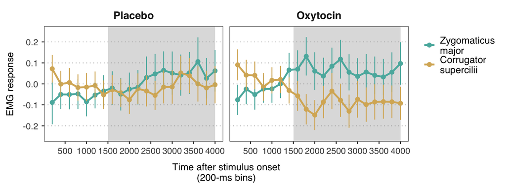

Figure 4. EMG responses to happy facial expressions of no-reward faces for each treatment group. Plotted data corresponds to Z-standardized, baseline-corrected EMG scores over 200-ms time-bins. Only the time-window between 1500 and 4000 ms post-stimulus onset (grey shade) was used for statistical analysis. Error bars represent within-subject 95% confidence intervals.

```r
# summarize data (within-subject, method from Morey 2008)
descr.emg.hap.norew <- Rmisc::summarySEwithin(data=subset(d.emg, reward=='No reward' & emotion=='Happy'),
                       measurevar='emg', betweenvars='treatment', withinvars=c('muscle'),
                       idvar='id', na.rm=FALSE, conf.interval=0.95)
colnames(descr.emg.hap.norew) <- c('Treatment', 'Muscle', 'N', 'M', 'SD', 'SE', 'CI')

kable(descr.emg.hap.norew[,c(1:2,4:6)], align='l', digits=2, caption='Descriptive statistics of zygomaticus major (ZM) and corrugator supercilii (CS) activity during the interval 1500-4000 ms post-stimulus onset, as a function of treatment group:') %>%
  kable_styling(bootstrap_options = c('hover', 'condensed', 'responsive'))
```

Descriptive statistics of zygomaticus major (ZM) and corrugator supercilii (CS) activity during the interval 1500-4000 ms post-stimulus onset, as a function of treatment group:

| Treatment | Muscle | M | SD | SE |
| --- | --- | --- | --- | --- |
| Placebo | ZM | 0.02 | 1.08 | 0.05 |
| Placebo | CS | -0.03 | 0.86 | 0.04 |
| Oxytocin | ZM | 0.08 | 1.10 | 0.05 |
| Oxytocin | CS | -0.08 | 0.93 | 0.04 |

**Model 1** revealed a main effect of `Muscle`, which confirms the occurance of facial mimicry of happiness: observation of happy facial expressions elicited higher ZM compared to CS activity. Contrary to our expectations, the interaction `Muscle*Treatment` was not significant, providing no evidence for a direct effect of oxytocin on mimicry of happiness.

```r
# MODEL 1: EMG responses to unconditioned happy faces

# select data
d.emg.hap <- subset(d.emg, emotion=='Happy' & reward=='No reward')

# RANDOM-effects structure: the maximal random-effects structure led to singular fit.
# By-participant and by-stimulus random slopes of muscle were dropped from the models.

# lmm
mh <- lmerTest::lmer(emg ~ muscle*treatment + (1|id) + (1|stimulus), data=d.emg.hap)
summary(mh, corr=F)
```

```
## Linear mixed model fit by REML. t-tests use Satterthwaite's method [
## lmerModLmerTest]
## Formula: emg ~ muscle * treatment + (1 | id) + (1 | stimulus)
##    Data: d.emg.hap
##
## REML criterion at convergence: 3814.5
##
## Scaled residuals:
##     Min      1Q  Median      3Q     Max
## -8.7983 -0.3657  0.0148  0.4006  7.2834
##
## Random effects:
##  Groups   Name        Variance Std.Dev.
##  id       (Intercept) 0.008302 0.09111
##  stimulus (Intercept) 0.003224 0.05678
##  Residual             0.514012 0.71695
## Number of obs: 1734, groups:  id, 56; stimulus, 6
##
## Fixed effects:
##                      Estimate Std. Error         df t value Pr(>|t|)
## (Intercept)        -5.882e-03  3.152e-02  6.600e+00  -0.187   0.8576
## muscle1             5.237e-02  1.723e-02  1.672e+03   3.040   0.0024 **
## treatment1          5.794e-02  2.135e-02  5.428e+01   2.714   0.0089 **
## muscle1:treatment1 -2.835e-02  1.723e-02  1.672e+03  -1.646   0.1000
## ---
## Signif. codes:  0 '***' 0.001 '**' 0.01 '*' 0.05 '.' 0.1 ' ' 1
```

```r
# estimated means for main effects
emm_options(lmer.df='Satterthwaite')
emm.h.muscle <- as.data.frame(emmeans(mh, 'muscle'))
emm.h.treatment <- as.data.frame(emmeans(mh, 'treatment'))

# table post-hoc results
kable(emm.h.muscle, digits=2, caption='Estimated means for the main effect of `Muscle`:') %>%
  kable_styling(bootstrap_options = c('hover', 'condensed', 'responsive'))
```

Estimated means for the main effect of `Muscle`:

| muscle | emmean | SE | df | lower.CL | upper.CL |
| --- | --- | --- | --- | --- | --- |
| ZM | 0.05 | 0.04 | 11.13 | -0.03 | 0.13 |
| CS | -0.06 | 0.04 | 11.13 | -0.14 | 0.02 |

```r
kable(emm.h.treatment, digits=2, caption='Estimated means for the main effect of `Treatment`:') %>%
  kable_styling(bootstrap_options = c('hover', 'condensed', 'responsive'))
```

Estimated means for the main effect of `Treatment`:

| treatment | emmean | SE | df | lower.CL | upper.CL |
| --- | --- | --- | --- | --- | --- |
| Placebo | 0.05 | 0.04 | 13.32 | -0.03 | 0.13 |
| Oxytocin | -0.06 | 0.04 | 12.51 | -0.15 | 0.02 |

### Mimicry of anger (*model 2*)

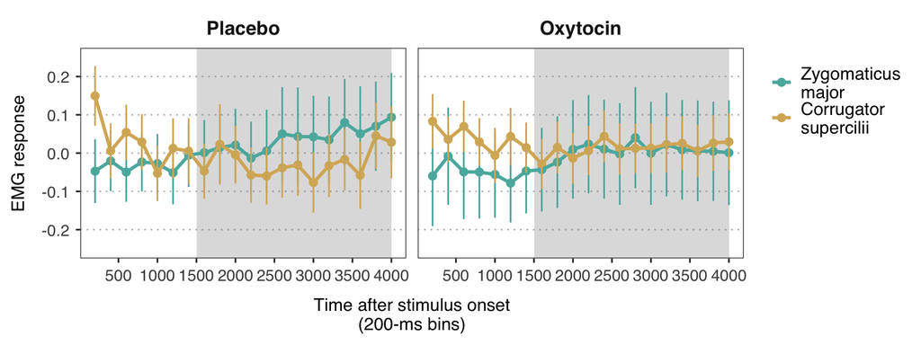

Figure 5. EMG responses to angry facial expressions of no-reward faces for each treatment group. Plotted data corresponds to Z-standardized, baseline-corrected EMG scores over 200-ms time-bins. Only the time-window between 1500 and 4000 ms post-stimulus onset (grey shade) was used for statistical analysis. Error bars represent within-subject 95% confidence intervals.

```r
# summarize data (within-subject, method from Morey 2008)
descr.emg.ang.norew <- Rmisc::summarySEwithin(data=subset(d.emg, reward=='No reward' & emotion=='Angry'),
                       measurevar='emg', betweenvars='treatment', withinvars=c('muscle'),
                       idvar='id', na.rm=FALSE, conf.interval=0.95)
colnames(descr.emg.ang.norew) <- c('Treatment', 'Muscle', 'N', 'M', 'SD', 'SE', 'CI')

kable(descr.emg.ang.norew[,c(1:2,4:6)], align='l', digits=2, caption='Descriptive statistics of zygomaticus major (ZM) and corrugator supercilii (CS) activity during the interval 1500-4000 ms post-stimulus onset, as a function of treatment group:') %>%
  kable_styling(bootstrap_options = c('hover', 'condensed', 'responsive'))
```

Descriptive statistics of zygomaticus major (ZM) and corrugator supercilii (CS) activity during the interval 1500-4000 ms post-stimulus onset, as a function of treatment group:

| Treatment | Muscle | M | SD | SE |
| --- | --- | --- | --- | --- |
| Placebo | ZM | 0.04 | 1.38 | 0.07 |
| Placebo | CS | -0.02 | 0.88 | 0.04 |
| Oxytocin | ZM | 0.00 | 1.75 | 0.08 |
| Oxytocin | CS | 0.01 | 0.78 | 0.04 |

**Model 2** did not reveal any significant effects. The non-significant main effect of `Muscle` suggests that our task failed to elicit congruent EMG responses to expressions of anger (i.e. CS was not significantly more activated than ZM).

```r
# MODEL 2: EMG responses to unconditioned angry faces

# select data
d.emg.ang <- subset(d.emg, emotion=='Angry' & reward=='No reward')

# RANDOM-effects structure: the maximal random-effects structure led to singular
# fit. By-participant and by-stimulus random slopes, as well as by-stimulus
# random intercept were dropped from the models.

# lmm
ma <- lmerTest::lmer(emg ~ muscle*treatment + (1|id), data=d.emg.ang)
summary(ma, corr=F)
```

```
## Linear mixed model fit by REML. t-tests use Satterthwaite's method [
## lmerModLmerTest]
## Formula: emg ~ muscle * treatment + (1 | id)
##    Data: d.emg.ang
##
## REML criterion at convergence: 4549.5
##
## Scaled residuals:
##      Min       1Q   Median       3Q      Max
## -20.8645  -0.2722   0.0034   0.2899  10.1358
##
## Random effects:
##  Groups   Name        Variance Std.Dev.
##  id       (Intercept) 0.01054  0.1027
##  Residual             0.82469  0.9081
## Number of obs: 1706, groups:  id, 56
##
## Fixed effects:
##                      Estimate Std. Error         df t value Pr(>|t|)
## (Intercept)         8.776e-03  2.596e-02  5.339e+01   0.338    0.737
## muscle1             1.408e-02  2.201e-02  1.648e+03   0.640    0.523
## treatment1         -2.920e-03  2.596e-02  5.339e+01  -0.112    0.911
## muscle1:treatment1  1.798e-02  2.201e-02  1.648e+03   0.817    0.414
```

## Mimicry of low & high reward faces

### Mimicry of happiness (*model 3*)

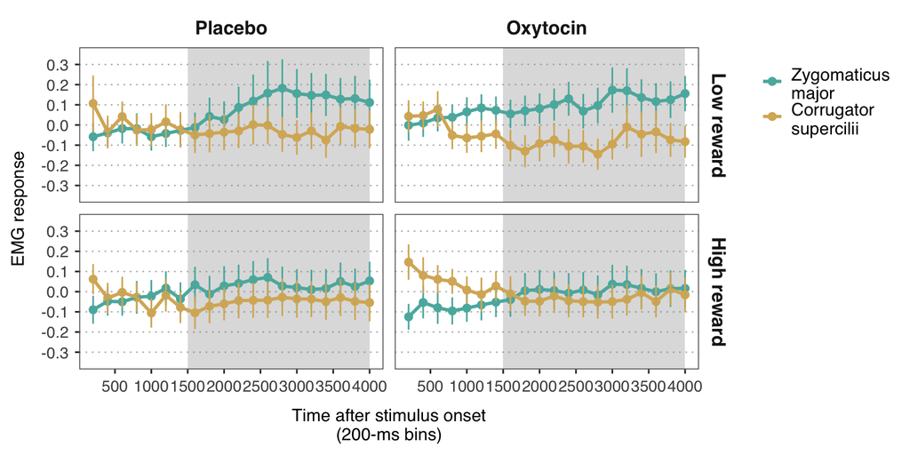

Figure 6. EMG responses to happy faces previously associated with low and high reward values for each treatment group. Plotted data corresponds to Z-standardized, baseline-corrected EMG scores over 200-ms time-bins. Only the time-window between 1500 and 4000 ms post-stimulus onset (grey shade) was used for statistical analysis. Error bars represent within-subject 95% confidence intervals.

```r
# summarize data (within-subject, method from Morey 2008)
descr.emg.hap.rew <- Rmisc::summarySEwithin(data=subset(d.emg, reward!='No reward' & emotion=='Happy' & learnt==TRUE),
                       measurevar='emg', betweenvars='treatment', withinvars=c('muscle', 'reward'),
                       idvar='id', na.rm=FALSE, conf.interval=0.95)
colnames(descr.emg.hap.rew) <- c('Treatment', 'Muscle', 'Reward', 'N', 'M', 'SD', 'SE', 'CI')

kable(descr.emg.hap.rew[,c(1:3,5:7)], align='l', digits=2, caption='Descriptive statistics of zygomaticus major (ZM) and corrugator supercilii (CS) activity during the interval 1500-4000 ms post-stimulus onset, as a function of treatment group and reward condition:') %>%
  kable_styling(bootstrap_options = c('hover', 'condensed', 'responsive'))
```

Descriptive statistics of zygomaticus major (ZM) and corrugator supercilii (CS) activity during the interval 1500-4000 ms post-stimulus onset, as a function of treatment group and reward condition:

| Treatment | Muscle | Reward | M | SD | SE |
| --- | --- | --- | --- | --- | --- |
| Placebo | ZM | Low reward | 0.11 | 0.97 | 0.05 |
| Placebo | ZM | High reward | 0.03 | 0.85 | 0.04 |
| Placebo | CS | Low reward | -0.04 | 0.76 | 0.04 |
| Placebo | CS | High reward | -0.06 | 0.74 | 0.04 |
| Oxytocin | ZM | Low reward | 0.12 | 0.73 | 0.04 |
| Oxytocin | ZM | High reward | 0.02 | 0.85 | 0.04 |
| Oxytocin | CS | Low reward | -0.08 | 0.71 | 0.04 |
| Oxytocin | CS | High reward | -0.03 | 0.70 | 0.04 |

**Model 3** yielded a significant `Muscle*Reward`, indicating that reward had an overall effect on mimicry of happiness. Follow-up analyses on the estimated means showed that, contrary to our expectations, participants mimicked happy expressions (i.e. ZM > CS) of low reward faces but not of high reward faces.

Neither the predicted three-way interaction, nor any of the two-way interactions with `Treatment` reached statistical significance.

```r
# MODEL 3: EMG responses to low and high reward happy faces

# select data
d.emg.rew.hap <- subset(d.emg, emotion=='Happy' & reward!='No reward' & learnt==TRUE)

# RANDOM-effects structure: the maximal random-effects structure led to singular fit.
# By-participant and by-stimulus random slopes of muscle, were dropped from the models.

# lmm
mh.rew <- lmerTest::lmer(emg ~ muscle*reward*treatment + (1|id) + (1|stimulus), data=d.emg.rew.hap)
summary(mh.rew, corr=F)
```

```
## Linear mixed model fit by REML. t-tests use Satterthwaite's method [
## lmerModLmerTest]
## Formula: emg ~ muscle * reward * treatment + (1 | id) + (1 | stimulus)
##    Data: d.emg.rew.hap
##
## REML criterion at convergence: 6640
##
## Scaled residuals:
##     Min      1Q  Median      3Q     Max
## -9.8840 -0.4072  0.0123  0.3878  8.5360
##
## Random effects:
##  Groups   Name        Variance Std.Dev.
##  id       (Intercept) 0.01342  0.11586
##  stimulus (Intercept) 0.00036  0.01897
##  Residual             0.53259  0.72979
## Number of obs: 2966, groups:  id, 51; stimulus, 6
##
## Fixed effects:
##                              Estimate Std. Error         df t value Pr(>|t|)
## (Intercept)                 9.823e-03  2.257e-02  1.358e+01   0.435    0.670
## muscle1                     5.859e-02  1.341e-02  2.901e+03   4.371 1.28e-05
## reward1                     2.023e-02  1.348e-02  1.777e+03   1.500    0.134
## treatment1                  2.630e-02  2.121e-02  4.807e+01   1.240    0.221
## muscle1:reward1             2.812e-02  1.341e-02  2.901e+03   2.098    0.036
## muscle1:treatment1         -1.657e-03  1.341e-02  2.901e+03  -0.124    0.902
## reward1:treatment1          4.841e-03  1.345e-02  2.550e+03   0.360    0.719
## muscle1:reward1:treatment1 -1.136e-02  1.341e-02  2.901e+03  -0.848    0.397
##
## (Intercept)
## muscle1                    ***
## reward1
## treatment1
## muscle1:reward1            *
## muscle1:treatment1
## reward1:treatment1
## muscle1:reward1:treatment1
## ---
## Signif. codes:  0 '***' 0.001 '**' 0.01 '*' 0.05 '.' 0.1 ' ' 1
```

```r
# sig. muscle*reward interaction:
emm.h.rew.muscle <- emmeans(mh.rew, ~ muscle)
emm.h.rew.muscle.reward <- emmeans(mh.rew, ~ muscle*reward)
mh.rew.posthoc.rew  <- as.data.frame(pairs(emm.h.rew.muscle.reward, by=c('reward'), adjust='none'))
mh.rew.posthoc.musc <- as.data.frame(pairs(emm.h.rew.muscle.reward, by=c('muscle'), adjust='none'))

# merge the 2 sets of post-hoc tests into a single table
names(mh.rew.posthoc.rew)[names(mh.rew.posthoc.rew) == 'reward'] <- ''
names(mh.rew.posthoc.musc)[names(mh.rew.posthoc.musc) == 'muscle'] <- ''
mh.rew.posthoc <- rbind(mh.rew.posthoc.rew, mh.rew.posthoc.musc)

# adjust p-value for multiple comparisons
mh.rew.posthoc$p.value <- p.adjust(mh.rew.posthoc$p.value, method='holm')

# table post-hoc results
kable(emm.h.rew.muscle, digits=2, caption='Estimated means for the main effect of `Muscle`:') %>%
  kable_styling(bootstrap_options = c('hover', 'condensed', 'responsive'))
```

Estimated means for the main effect of `Muscle`:

| muscle | emmean | SE | df | lower.CL | upper.CL |
| --- | --- | --- | --- | --- | --- |
| ZM | 0.07 | 0.03 | 24.88 | 0.01 | 0.12 |
| CS | -0.05 | 0.03 | 24.88 | -0.10 | 0.01 |

```r
kable(emm.h.rew.muscle.reward, digits=2, caption='Estimated means for the interaction `Muscle*Reward`:') %>%
  kable_styling(bootstrap_options = c('hover', 'condensed', 'responsive'))
```

Estimated means for the interaction `Muscle*Reward`:

| muscle | reward | emmean | SE | df | lower.CL | upper.CL |
| --- | --- | --- | --- | --- | --- | --- |
| ZM | Low reward | 0.12 | 0.03 | 56.49 | 0.05 | 0.18 |
| CS | Low reward | -0.06 | 0.03 | 56.49 | -0.12 | 0.01 |
| ZM | High reward | 0.02 | 0.03 | 54.92 | -0.05 | 0.09 |
| CS | High reward | -0.04 | 0.03 | 54.92 | -0.11 | 0.02 |

```r
kable(mh.rew.posthoc, digits=2, caption='Follow-up tests for the interaction `Muscle*Reward`:') %>%
  kable_styling(bootstrap_options = c('hover', 'condensed', 'responsive'))
```

Follow-up tests for the interaction `Muscle*Reward`:

| contrast |  | estimate | SE | df | t.ratio | p.value |
| --- | --- | --- | --- | --- | --- | --- |
| ZM - CS | Low reward | 0.17 | 0.04 | 2901.45 | 4.58 | 0.00 |
| ZM - CS | High reward | 0.06 | 0.04 | 2901.45 | 1.60 | 0.22 |
| Low reward - High reward | ZM | 0.10 | 0.04 | 2552.70 | 2.54 | 0.03 |
| Low reward - High reward | CS | -0.02 | 0.04 | 2552.70 | -0.42 | 0.68 |

### Mimicry of anger (*model 4*)

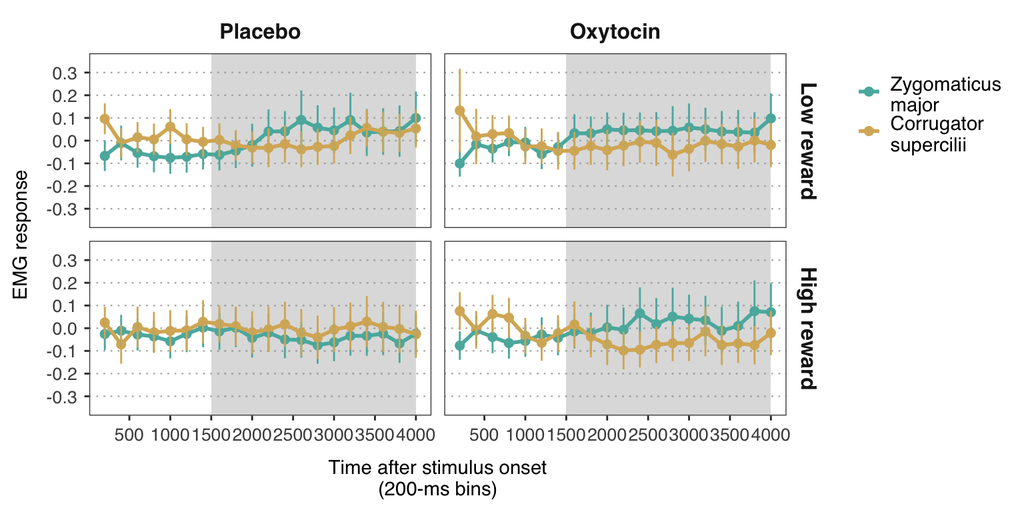

Figure 7. EMG responses to angry faces previously associated with low and high reward values for each treatment group. Plotted data corresponds to Z-standardized, baseline-corrected EMG scores over 200-ms time-bins. Only the time-window between 1500 and 4000 ms post-stimulus onset (grey shade) was used for statistical analysis. Error bars represent within-subject 95% confidence intervals.

```r
# summarize data (within-subject, method from Morey 2008)
descr.emg.ang.rew <- Rmisc::summarySEwithin(data=subset(d.emg, reward!='No reward' & emotion=='Angry' & learnt==TRUE),
                       measurevar='emg', betweenvars='treatment', withinvars=c('muscle', 'reward'),
                       idvar='id', na.rm=FALSE, conf.interval=0.95)
colnames(descr.emg.ang.rew) <- c('Treatment', 'Muscle', 'Reward', 'N', 'M', 'SD', 'SE', 'CI')

kable(descr.emg.ang.rew[,c(1:3,5:7)], align='l', digits=2, caption='Descriptive statistics of zygomaticus major (ZM) and corrugator supercilii (CS) activity during the interval 1500-4000 ms post-stimulus onset, as a function of treatment group and reward condition:') %>%
  kable_styling(bootstrap_options = c('hover', 'condensed', 'responsive'))
```

Descriptive statistics of zygomaticus major (ZM) and corrugator supercilii (CS) activity during the interval 1500-4000 ms post-stimulus onset, as a function of treatment group and reward condition:

| Treatment | Muscle | Reward | M | SD | SE |
| --- | --- | --- | --- | --- | --- |
| Placebo | ZM | Low reward | 0.04 | 0.85 | 0.04 |
| Placebo | ZM | High reward | -0.04 | 0.76 | 0.04 |
| Placebo | CS | Low reward | 0.00 | 0.62 | 0.03 |
| Placebo | CS | High reward | -0.01 | 0.87 | 0.05 |
| Oxytocin | ZM | Low reward | 0.05 | 0.75 | 0.04 |
| Oxytocin | ZM | High reward | 0.03 | 0.96 | 0.05 |
| Oxytocin | CS | Low reward | -0.02 | 0.81 | 0.04 |
| Oxytocin | CS | High reward | -0.06 | 0.76 | 0.04 |

**Model 4** did not yield any significant main effects nor interactions.

```r
# MODEL 4: EMG responses to low and high reward happy faces

# select data
d.emg.rew.ang <- subset(d.emg, emotion=='Angry' & reward!='No reward' & learnt==TRUE)

# RANDOM-effects structure: the maximal random-effects structure led to singular fit.
# By-participant and by-stimulus random slopes of muscle, were dropped from the models.

# lmm
ma.rew <- lmerTest::lmer(emg ~ muscle*reward*treatment + (1|id) + (1|stimulus), data=d.emg.rew.ang)
summary(ma.rew, corr=F)
```

```
## Linear mixed model fit by REML. t-tests use Satterthwaite's method [
## lmerModLmerTest]
## Formula: emg ~ muscle * reward * treatment + (1 | id) + (1 | stimulus)
##    Data: d.emg.rew.ang
##
## REML criterion at convergence: 6635.1
##
## Scaled residuals:
##      Min       1Q   Median       3Q      Max
## -12.6464  -0.3394   0.0257   0.3878  11.8257
##
## Random effects:
##  Groups   Name        Variance  Std.Dev.
##  id       (Intercept) 0.0026213 0.05120
##  stimulus (Intercept) 0.0003018 0.01737
##  Residual             0.5465290 0.73928
## Number of obs: 2944, groups:  id, 51; stimulus, 6
##
## Fixed effects:
##                              Estimate Std. Error         df t value Pr(>|t|)
## (Intercept)                -1.514e-03  1.702e-02  6.652e+00  -0.089    0.932
## muscle1                     2.014e-02  1.363e-02  2.884e+03   1.477    0.140
## reward1                     1.720e-02  1.369e-02  1.864e+03   1.256    0.209
## treatment1                 -4.382e-03  1.548e-02  4.639e+01  -0.283    0.778
## muscle1:reward1             7.258e-03  1.363e-02  2.884e+03   0.532    0.594
## muscle1:treatment1         -1.952e-02  1.363e-02  2.884e+03  -1.432    0.152
## reward1:treatment1          3.873e-03  1.366e-02  2.565e+03   0.283    0.777
## muscle1:reward1:treatment1  1.155e-02  1.363e-02  2.884e+03   0.847    0.397
```

## Equivalence testing

Given that there is no clear theoretical boundary for oxytocin’s social-cognitive effects for setting the equivalence bounds (Quintana, 2018), we defined the smallest effect size of interest based on the smallest effect size detectable with 80% power given our sample size (Quintana, 2018; Tabak et al., 2019). The alpha level was set to 0.05.

### Effect of oxytocin on mimicry of happiness

First, we applied the TOST procedure to test the null effect of oxytocin on EMG responses to happy expressions of unconditioned faces. Given that the TOST procedure is based on t-tests, we reduced the original interaction `Muscle*Treatment` tested in the LMM by computing mimicry indices (i.e. difference score between CS and ZM activity in response to happy faces) for each participant. Positive scores indicate the occurrence of mimicry of happiness.

```r
# Compute average EMG responses
d.tost <- d.emg[d.emg$reward=='No reward',] %>%
  dplyr::group_by(id, treatment, emotion, muscle, reward) %>%
  dplyr::summarise(emg=mean(emg))

d.tost$muscle <- factor(d.tost$muscle, levels=c('ZM', 'CS'), labels=c('zm', 'cs'))
d.tost$emotion <- factor(d.tost$emotion, levels=c('Happy', 'Angry'), labels=c('hap', 'ang'))
d.tost$reward <- factor(d.tost$reward, levels=c('No reward'), labels=c('norew'))
d.tost$varname<- with(d.tost, paste(muscle, emotion, reward, sep='_'))
d.tost<- d.tost[,c('id', 'treatment', 'varname', 'emg')]
d.tost <- tidyr::spread(data=d.tost, key=varname, value=emg)

# Compute mimicry indices (ZM minus CS)
d.tost$mim_hap_norew <- d.tost$zm_hap_norew-d.tost$cs_hap_norew
d.tost$mim_ang_norew <- d.tost$zm_ang_norew-d.tost$cs_ang_norew
```

Based on the equivalence test and the null-hypothesis test combined, we can conclude that the observed effect is statistically not different from zero and statistically not equivalent to zero.

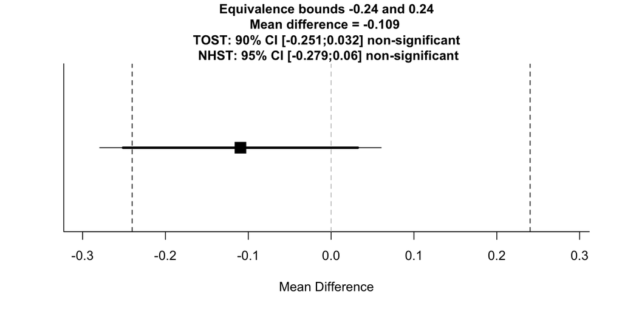

```r
# Define the SESOI based on the smallest detectable effect size
smallest_es <- pwr::pwr.t2n.test(power=0.8, n1=sum(d.tost$treatment=='Placebo'), n2=sum(d.tost$treatment=='Oxytocin'), alternative='two.sided', sig.level=0.05)
seosi <- smallest_es$d

# TOST procedure: mimicry of HAPPINESS (oxt vs. plc)
tost_norew <- TOSTER::TOSTtwo(m1=mean(d.tost$mim_hap_norew[d.tost$treatment=='Placebo']),
                              m2=mean(d.tost$mim_hap_norew[d.tost$treatment=='Oxytocin']),
                              sd1=sd(d.tost$mim_hap_norew[d.tost$treatment=='Placebo']),
                              sd2=sd(d.tost$mim_hap_norew[d.tost$treatment=='Oxytocin']),
                              n1=sum(d.tost$treatment=='Placebo'), n2=sum(d.tost$treatment=='Oxytocin'),
                              low_eqbound_d=-seosi, high_eqbound_d=seosi,
                              var.equal=FALSE, alpha=0.05, verbose=FALSE, plot=TRUE)
```

### Effect of oxytocin on the reward modulation of mimicry of happiness

```r
# Compute average EMG responses, excl. unlearnt trials
d.tost.rew <- d.emg[d.emg$reward!='No reward' & d.emg$learnt==TRUE,] %>%
  dplyr::group_by(id, treatment, emotion, muscle, reward) %>%
  dplyr::summarise(emg=mean(emg))

d.tost.rew$muscle <- factor(d.tost.rew$muscle, levels=c('ZM', 'CS'), labels=c('zm', 'cs'))
d.tost.rew$emotion <- factor(d.tost.rew$emotion, levels=c('Happy', 'Angry'), labels=c('hap', 'ang'))
d.tost.rew$reward <- factor(d.tost.rew$reward, levels=c('Low reward', 'High reward'), labels=c('lorew', 'hirew'))
d.tost.rew$varname<- with(d.tost.rew, paste(muscle, emotion, reward, sep='_'))
d.tost.rew<- d.tost.rew[,c('id', 'treatment', 'varname', 'emg')]
d.tost.rew <- tidyr::spread(data=d.tost.rew, key=varname, value=emg)

# Compute mimicry indices and difference score for reward condition (High reward - Low reward)
d.tost.rew$mim_hap_lorew <- d.tost.rew$zm_hap_lorew-d.tost.rew$cs_hap_lorew
d.tost.rew$mim_ang_lorew <- d.tost.rew$zm_ang_lorew-d.tost.rew$cs_ang_lorew
d.tost.rew$mim_hap_hirew <- d.tost.rew$zm_hap_hirew-d.tost.rew$cs_hap_hirew
d.tost.rew$mim_ang_hirew <- d.tost.rew$zm_ang_hirew-d.tost.rew$cs_ang_hirew
d.tost.rew$mim_hap_rewdiff <- d.tost.rew$mim_hap_hirew-d.tost.rew$mim_hap_lorew
d.tost.rew$mim_ang_rewdiff <- d.tost.rew$mim_ang_hirew-d.tost.rew$mim_ang_lorew
```

Based on the equivalence test and the null-hypothesis test combined, we can conclude that the observed effect is statistically not different from zero and statistically not equivalent to zero.

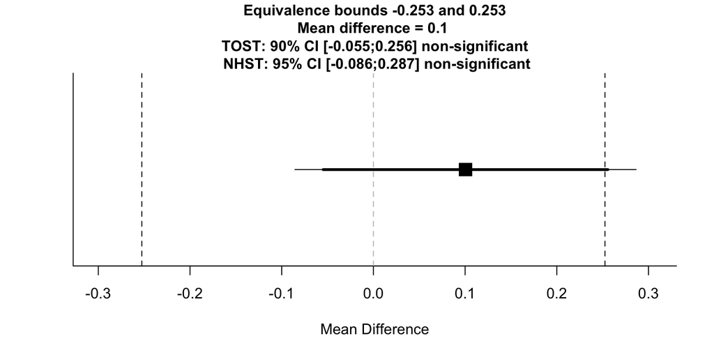

```r
# Define the SESOI based on the smallest detectable effect size
smallest_es_rew <- pwr::pwr.t2n.test(power=0.8, n1=sum(d.tost.rew$treatment=='Placebo'), n2=sum(d.tost.rew$treatment=='Oxytocin'), alternative='two.sided', sig.level=0.05)
seosi_rew <- smallest_es_rew$d

# TOST procedure: mimicry of HAPPINESS (oxt vs. plc)
tost_rew <- TOSTER::TOSTtwo(m1=mean(d.tost.rew$mim_hap_rewdiff[d.tost.rew$treatment=='Placebo']),
                            m2=mean(d.tost.rew$mim_hap_rewdiff[d.tost.rew$treatment=='Oxytocin']),
                            sd1=sd(d.tost.rew$mim_hap_rewdiff[d.tost.rew$treatment=='Placebo']),
                            sd2=sd(d.tost.rew$mim_hap_rewdiff[d.tost.rew$treatment=='Oxytocin']),
                            n1=sum(d.tost.rew$treatment=='Placebo'), n2=sum(d.tost.rew$treatment=='Oxytocin'),
                              low_eqbound_d=-seosi, high_eqbound_d=seosi,
                              var.equal=FALSE, alpha=0.05, verbose=FALSE, plot=TRUE)
```

# References

Lakens, D. (2017). Equivalence Tests: A Practical Primer for t Tests, Correlations, and Meta-Analyses. Social Psychological and Personality Science, 8(4), 355–362. https://doi.org/10.1177/1948550617697177

Mutz, D. C., Pemantle, R., & Pham, P. (2019). The Perils of Balance Testing in Experimental Design: Messy Analyses of Clean Data. The American Statistician, 73(1), 32–42. https://doi.org/10.1080/00031305.2017.1322143

Quintana, D. S. (2018). Revisiting non-significant effects of intranasal oxytocin using equivalence testing. Psychoneuroendocrinology, 87, 127–130. https://doi.org/10.1016/j.psyneuen.2017.10.010

Tabak, B. A., Teed, A. R., Castle, E., Dutcher, J. M., Meyer, M. L., Bryan, R., … Eisenberger, N. I. (2019). Null results of oxytocin and vasopressin administration across a range of social cognitive and behavioral paradigms: Evidence from a randomized controlled trial. Psychoneuroendocrinology, 107, 124–132. https://doi.org/10.1016/j.psyneuen.2019.04.019